# Market reactions to announcements of corporate downsizing actions and implementation strategies

Converted from PDF `Nixon-MarketReactionsDownsizing-2004-SMJ.pdf` · 9 pages · anchors: page `#pN`, block `#pN-bK`

Page 1

*Strategic Management Journal*

*Strat. Mgmt. J.*, **25**: 1121–1129 (2004) Published online in Wiley InterScience (www.interscience.wiley.com). DOI: 10.1002/smj.423

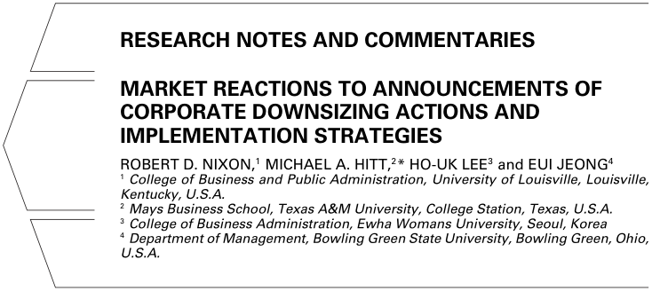

**text found inside the figure**

**RESEARCH NOTES AND COMMENTARIES**

**MARKET REACTIONS TO ANNOUNCEMENTS OF CORPORATE DOWNSIZING ACTIONS AND IMPLEMENTATION STRATEGIES**

ROBERT D. NIXON,<sup>1</sup> MICHAEL A. HITT,<sup>2</sup>* HO-UK LEE<sup>3</sup> and EUI JEONG<sup>4</sup>

1 College of Business and Public Administration, University of Louisville, Louisville, Kentucky, U.S.A. 2 Mays Business School, Texas A&M University, College Station, Texas, U.S.A. 3 College of Business Administration, Ewha Womans University, Seoul, Korea 4 Department of Management, Bowling Green State University, Bowling Green, Ohio, U.S.A.

*This study examines the effects of downsizing actions and implementation strategies on market performance. While downsizing actions reduce costs, they also produce a loss of valuable human capital that can exceed the benefits resulting from the lay-offs. In support of this argument, the results showed that downsizing had a negative effect on market returns and the effects grow increasingly negative with larger downsizing actions. However, the market reacts more positively to downsizing actions when reallocation strategies are used and to large downsizing actions when disengagement incentives are applied. The results of this research suggest the importance of carefully managing valuable resources to create positive returns.* Copyright 2004 John Wiley & Sons, Ltd.

Downsizing (involuntary turnover) through layoffs is a common feature of corporate life in the United States (Bowman and Singh, 1993; Cascio, 1993, 2002; Mroczkowski and Hanaoka, 1997). Downsizing occurs even more frequently in difficult economic times because of firms’ desire to reduce expenses; human capital costs are variable expenses that are more easily reduced (Cascio, 2002). But, while firms reduce costs when employees are laid off, they also lose valuable resources, notably knowledge that is critical for achieving and sustaining a competitive advantage (for a review see Jackson, Hitt, and DeNisi,

Keywords: downsizing; human capital; implementation; reallocation strategies; disengagement incentives *Correspondence to: Michael A. Hitt, Mays Business School, Texas A&M University, College Station, TX 77843-4221, U.S.A. E-mail: mhitt@cgsb.tamu.edu.edu

2003). Some important knowledge is embedded in organizational routines but the knowledge most critical for competitive advantage, tacit knowledge, is usually held by individuals in the firm. Thus, when firms lay off thousands of employees, especially in the professional and managerial ranks as exemplified in recent times (Cascio, 2002), they lose valuable knowledge. Furthermore, if the layoffs are not carefully planned and implemented, firms may harm their core capabilities that provide the basis for a competitive advantage.

The purpose of this study is to examine the effects of downsizing announcements on market returns; we are especially interested in the outcomes of large downsizing actions where losses of important human capital are likely. Additionally, we examine the effects of different implementation actions on the downsizing–market returns relationship. We control for other potential explanations

Copyright 2004 John Wiley & Sons, Ltd. *Received 10 July 2000 Final revision received 31 March 2004*

Page 2

1122 *R. D. Nixon et al.*

for the outcomes such as the prior performance of the firm, its size, human asset intensity, efficiency motives, level of diversification, and downscoping.

Our results support the importance of human capital and especially knowledge to the creation of firm value with significant negative returns attributed to larger downsizing actions. Additionally, the study suggests the importance of managing downsizing effectively as the returns are positive when effective downsizing implementation actions are used. The study provides important implications for future research on downsizing and for managers deciding to take such actions.

#### **THEORETICAL FRAMEWORK**

Downsizing can be defined as an intentional, permanent, and systematic reduction of an organization’s workforce (DeWitt, 1993; Freeman and Cameron, 1993). Thus, downsizing reduces a firm’s human capital and consequently affects firm performance. Human capital is important for firm performance because it holds, diffuses, and applies knowledge that is a critical base for gaining a competitive advantage (Grant, 1996). Based on this premise, Hitt *et al*. (2001) suggested that one answer to the critical question in strategic management about why firms vary in performance is the heterogeneity in human capital across firms.

Knowledge, especially tacit knowledge, is an important intangible resource that is often valuable, rare, and difficult to duplicate (as knowledge accumulation is socially complex) and thus can serve as a foundation for a firm’s competitive advantage (Barney, 1991; Dierickx and Cool, 1989; Penrose, 1959; Wernerfelt, 1984, 1995). While some knowledge is embedded in organizational routines, most of the valuable knowledge is held by a firm’s human capital. The selection, development, and retention of human resources, i.e., human capital, is critical for building and sustaining a firm’s inventory of knowledge (Levinthal and March, 1993). A firm’s knowledge is leveraged to achieve and maintain a competitive advantage (Hitt *et al*., 2001), Downsizing directly affects the quantity of valuable human capital and thus the knowledge in the firm; that is, downsizing is likely to produce a loss of valuable knowledge, especially large downsizing actions, and thereby harm its ability to sustain a competitive advantage.

A firm’s human capital not only holds knowledge but also represents a ‘social community’ for knowledge creation, diffusion, and utilization (Spender, 1996; Zander and Kogut, 1995). The social community facilitates interactions among people in the firm that promote the creation and diffusion of knowledge, especially tacit knowledge, and this knowledge becomes organizationally embedded. When embedded, the firm’s ‘knowledge inventory’ (Levinthal and March, 1993) is enhanced. Downsizing actions, however, can disrupt the operation of the ‘social community’ for knowledge creation and/or sharing within the firm and also affect managers’ options for current and future use of the firm’s ‘knowledge inventory’ (Miller, 2002). Reductions in the human capital can disrupt the ‘social community’ by eliminating working relationships in which tacit knowledge was diffused. Time and focus of managers are required to rebuild new relationships and reenergize the knowledge diffusion process after downsizing has been implemented.

According to Cascio (2002), the effectiveness of management actions is ultimately judged on the criterion of the attractiveness of stock returns generated to investors. Therefore, downsizing is often intended to improve firm performance as reflected in the market value of the firm (Cascio, Young, and Morris, 1997). Investors react to the announcements of major strategic moves thereby affecting the stock returns. Public announcements of corporate downsizing generally include information regarding the level of the intended reduction (i.e., the number or percentage of employees to be terminated). The announcement of downsizing provides a signal to the market regarding the firm’s current state as well as its future ability to compete effectively in the marketplace. While it signals a reduction in costs, it also signals a loss of human capital and thus a loss of valuable knowledge, and a reduced ability to create and diffuse knowledge. However, large downsizings may have especially severe effects. In fact, a major loss of human capital is likely to disrupt a firm’s bundles of resources and thereby downgrade its set of capabilities necessary to create and sustain a competitive advantage (Sirmon, Hitt, and Ireland, 2003). As such, the effect of downsizing on stock returns should become increasingly negative (downward slope becomes more negative at an increasing rate). Based on these arguments, we offer the following hypothesis:

Copyright 2004 John Wiley & Sons, Ltd. *Strat. Mgmt. J.*, **25**: 1121–1129 (2004)

Page 3

*Research Notes and Commentaries* 1123

*Hypothesis 1: The level of downsizing has a negative curvilinear effect on the market valuation of the firm.*

The effects of downsizing on the firm’s human capital and capabilities can be moderated by using implementation approaches that target less valuable resources for lay-off. A reallocation strategy exemplifies such an approach. A reallocation strategy refers to specific decisions regarding those to be laid off or which departments will be reduced (Ludwig, 1993). Reallocation describes the *distribution* of the employee reduction among the firm’s units. Low reallocation suggests wide, sometimes shallow, across-the-board cuts in the number of employees requiring all units to reduce personnel by an equal amount or a uniform percentage. In contrast, high reallocation indicates deep, selective or focused reductions targeting specific units or functions. The market usually responds more positively to selective reductions because of the assumption that the targeted units or functions are of lower value to the firm than others and that the changes will have a small or no effect on the firm’s most important capabilities (i.e., those serving as a base for competitive advantage). Whereas, an across-the-board reduction (low reallocation) could seriously harm the firm’s most important capabilities; such an approach does not buffer the human capital most valuable to the firm. Acrossthe-board reductions may disrupt important interpersonal relationships and networks. But, more targeted reallocation actions are less likely to disrupt these critical networks and working relationships through which the firm’s most valuable knowledge is transmitted. Investors then are likely to perceive downsizing using a high reallocation strategy as reducing costs (increasing efficiency) without harming the firm’s capabilities to create and sustain a competitive advantage. As a result, the reallocation strategy is likely to moderate the effect of downsizing on market returns. These arguments lead to the following hypotheses:

*Hypothesis 2a: The announcement of a high reallocation downsizing strategy has a positive effect on the market valuation of the firm.*

*Hypothesis 2b: The announcement of a high reallocation strategy positively moderates the relationship between a firm’s level of downsizing and the market valuation of the firm.*

Use of disengagement incentives is another form of implementation strategy to facilitate downsizing initiatives. Disengagement incentives are offered to employees to entice them to voluntarily leave the organization. Such incentives include extraordinary cash payments, additional credit for time employed (increasing retirement benefits), and the extension of existing salary or other benefits (e.g., health insurance) normally halted upon termination. Disengagement incentives, however, represent costs charged against current profits (Dalton, Daily, and Kesner, 1993). Additionally, when the cost of leaving for valuable employees is reduced, they are more likely to depart. For example, Bowman and Singh (1993) found that when an attractive early retirement package was offered, the most valuable employees often took advantage of the incentives and departed. Even if the firm replaces some of the departing employees, they frequently do so with new employees having much less experience (lower cost to the firm but also less tacit knowledge). They then experience training costs and productivity losses until the new employee connects into the knowledge generating ‘social community’ and gains adequate skills to perform the job in an acceptable manner. Therefore, disengagement incentives are likely to elicit a negative stock market reaction (Worrell, Davidson, and Sharma, 1991).

The use of disengagement incentives, however, is expected to positively moderate the relationship between the level of downsizing and the market valuation of the firm. While incentives often entice high-quality human capital to depart, they make it easier for managers to achieve higher levels of downsizing. The use of such incentives also produces a more positive attitude among survivors (Brockner, 1990), because it assuages (or avoids) their feeling of guilt for not being laid off when their colleagues lost their jobs. Survivors with positive attitudes will be more productive after the downsizing. These arguments lead to the following hypotheses:

*Hypothesis 3a: The announcement of disengagement incentives has a negative effect on the market valuation of the firm.*

*Hypothesis 3b: The announcement of disengagement incentives positively moderates the relationship between a firm’s level of downsizing and market valuation of the firm.*

Copyright 2004 John Wiley & Sons, Ltd. *Strat. Mgmt. J.*, **25**: 1121–1129 (2004)

Page 4

1124 *R. D. Nixon et al.*

#### **Sample**

The sample for this study is based on downsizing announcements and respective stock price reactions between January 1990 and December 1998. Initially we collected 1445 downsizing announcements by U.S.-based firms in the *Wall Street Journal*. We eliminated announcements that lacked sufficient information on downsizing implementation strategies or necessary financial or stock price data, described minor downsizing events (level of downsizing is less than 0.5% of the total employees), or had potential confounding events within 5 days previous to the focal announcement, as recommended by McWilliams and Siegel (1997). Applying these criteria resulted in the final sample size of 364 announcements. In addition to the *Wall Street Journal*, we collected data from other sources such as Standard & Poor’s COMPUSTAT databases (firms’ annual financial and industry segment data) and the *Center for Research in Security Prices* (CRSP) databases (raw stock returns).

#### **Dependent variable**

The dependent variable is market valuation of the firm, operationalized as the cumulative abnormal daily stock returns (CAR) observed at the time of the downsizing announcement. Event study methodology common to financial research (Brown and Warner, 1985) was used to calculate the CAR over a narrow 3-day event window (McWilliams and Siegel, 1997) that included the day prior to, the day of, and the day following the announcement in the *Wall Street Journal*.

#### **Independent variables**

*Level of downsizing*

The level of downsizing was operationalized as the percentage reduction in total employees in the firm as announced in the *Wall Street Journal*. As a step to create the squared term, the first-order term was first mean-centered.

*Reallocation level*

Using a 0/1 binary variable, downsizing announcements that signaled a low reallocation strategy (broad-based, across-the-board) were coded as 0.

Those announcements that signaled a high reallocation strategy (more targeted area or specific unit) were coded as 1. Two independent raters analyzed each announcement regarding the firm’s reallocation strategy. Initial interrater reliability was 0.90. Total agreement was achieved through discussion by the raters.

*Disengagement incentives*

The use of distinct disengagement incentives was identified by evaluating the announcements. This variable was coded as 1 if disengagement incentives were offered and 0 otherwise. Two independent raters analyzed and scored each announcement. The initial interrater reliability was 0.97, with total agreement achieved through interrater discussions.

To ensure the accuracy of the information in the *Wall Street Journal* announcements on the independent variables, we corroborated the data using a number of regional daily and other periodic business publications (identified in *Business Insite* and *Lexis-Nexis*).

#### **Control variables**

We controlled for a number of alternative explanations for negative returns. For example, we controlled for *prior firm performance* using the total market return for the entire year prior to the day of announcement. This total market return was calculated by summing the stock price returns of a firm during the entire year (usually 255 trading days) prior to the day of announcement. To control for differences in available resources across firms, the log transformation of total assets was used to represent *firm size*. To control for the different starting points in the firms’ need to downsize, *previous firm efficiency* was obtained by dividing total sales in the year before downsizing by the number of employees prior to downsizing, and adjusting for industry effects by subtracting the optimum efficiency (average sales/employee of firms with sales equal to or above 95% of all firms in the same industry). The *human asset intensity* (Coff, 1999) for each firm was operationalized as the firm’s labor and related expenses (salary and fringe benefits) divided by firm sales for the year prior to downsizing. The average human asset intensity for each firm’s industry (weighted by each firm’s size in total assets) was

Copyright 2004 John Wiley & Sons, Ltd. *Strat. Mgmt. J.*, **25**: 1121–1129 (2004)

Page 5

*Research Notes and Commentaries* 1125

then calculated. The entropy measure (Hoskisson *et al*., 1993; Palepu, 1985) was used to control for the *diversification* level of the sample firms prior to their downsizing announcement. To control for, and distinguish, downscoping from downsizing, changes from the firm’s pre- to the postdownsizing level of diversification were measured. Pre-downsizing total diversification was subtracted from post-downsizing total diversification, providing a continuous measure of *change in diversification level*. To control for market anticipation of changes such as downsizing announcements, we identified all *changes in CEO* for the sample firms for up to 6 months prior to the downsizing announcement. The variable was coded as a 1 for CEO changes and 0 otherwise. Finally, a *trend variable*, 1990 (+1) to 1998 (+9), was included to control for possible imitation/bandwagon effects among firms.

#### **RESULTS**

Model 3b adds two interaction terms (both with reallocation strategies) showing that the interaction with the squared term is positive and statistically significant consistent with the prediction. While the interaction coefficient of the first-order term was not statistically significant, the *χ*<sup>2</sup> difference is statistically significant *(p <* 0*.*05*)*, indicating there is a moderating effect. Thus, Hypothesis 2b receives support.

Models 4a and 4b test the main and moderating effects of using *Disengagement Incentives*. As shown in Model 4a, the main effect was not statistically significant. However, the interaction with the squared term is positive and statistically significant (Model 4b). Furthermore, the *χ*<sup>2</sup> difference is statistically significant *(p <* 0*.*01*)* in support of a moderating effect for disengagement incentives. Thus, Hypothesis 3a received no support but the results provide support for Hypothesis 3b.

Plots of the moderating relationships (available from the authors upon request) show that without the use of a reallocation strategy, or without the use of disengagement incentives, the CARs increase slightly with small amounts of downsizing but then become negative at an increasing rate with greater downsizing. However, when

Copyright 2004 John Wiley & Sons, Ltd. *Strat. Mgmt. J.*, **25**: 1121–1129 (2004)

Page 6

1126 *R. D. Nixon et al.*

Table 1. Descriptive statistics and correlation coefficients

1. Market Performance (CAR) −0.0041 0.0626

2. Level of Downsizing (LD) 0.0000 0.0992 −0.10∗

*N* = 364; ∗*p <* 0*.*05

Copyright 2004 John Wiley & Sons, Ltd. *Strat. Mgmt. J.*, **25**: 1121–1129 (2004)

Page 7

*Research Notes and Commentaries* 1127

Table 2. GLS results for market performance (cumulative abnormal return)

Independent variables

+ *p <* 0*.*1; ∗*p <* 0*.*05; ∗∗*p <* 0*.*01 Note: The differences of d.f.’s are the differences against the previous model (e.g., d.f. of Model 2a −d.f. of Model 2b).

reallocation strategies are used, the CARs are positive and relatively level (increasing at a decreasing rate) with higher levels of downsizing. And, when disengagement incentives are used to implement downsizing, CARs are positive and increase at an increasing rate.

Finally, examination of Model 5 suggests that the results are robust. With all variables entered into the model, all but one coefficient that were statistically significant in the earlier models remain statistically significant in the full model.

#### **DISCUSSION**

Overall, the results provide support for the resource-based view suggesting that resources are a critical determinant of firm performance. Importantly, the research suggests that loss of valuable human capital through downsizing is viewed negatively in the capital markets, and even more so with large downsizing actions. These results are especially salient given the control for potentially compelling alternative explanations for the negative

Copyright 2004 John Wiley & Sons, Ltd. *Strat. Mgmt. J.*, **25**: 1121–1129 (2004)

Page 8

1128 *R. D. Nixon et al.*

outcomes such as prior performance, level of and change in the firm’s diversification level, previous firm efficiency, change in the CEO and the human asset intensity of the industry in which the firm operates. Thus, we conclude that while managers often downsize to reduce expenses, the market generally views such actions negatively because of concerns that losses in valuable human capital will exceed the benefits gained from lower costs.

The results also suggest that managers can reduce or eliminate the negative effect of downsizing through the implementation strategies used. Particularly important are reallocation strategies in which specific units or areas are targeted for reductions. In this way, the managers are able to avoid losses of the most valuable human capital to the firm. Managers can target units and functions for reduction that are outside of the firm’s core capabilities and make changes that are the least disruptive to the social community. As such, the firm can reduce costs while maintaining its core capabilities, continue to create and diffuse knowledge, and keep its competitive advantage intact. Additionally, disengagement strategies can be useful when the firm must undertake especially large downsizing actions. They facilitate the firm’s achievement of employee reduction goals and help survivors to avoid major guilt feelings for not being laid off. In this way, the firm is able to meet its cost reduction targets while maintaining a desired level of productivity with the continuing workforce (survivors). The plots of the moderating effects of both implementation strategies clearly show the largely negative effect of downsizing on market valuation to become positive when each of these strategies are used.

An important implication of this study is that investors perceive that downsizing actions are unlikely to provide solutions to major problems in the firm; in fact, they may exacerbate them because of the loss of valuable human capital. Thus, perhaps downsizing should not be used for a primary cost reduction move except in special cases because it is likely to harm market valuations of the firm rather than help them. Furthermore, if downsizing is required, it should be carefully planned and managed through effective downsizing implementation strategies.

The results of this study suggest the criticality of dedicated attention given to the management of a firm’s resources. Firms must protect their valuable

resources and core capabilities in order to maintain their competitive advantages. While divesting resources may be necessary at times, managers must carefully select those to be discarded and protect those most valuable to the firm’s competitive advantage. Only when these managerial actions accompany downsizing actions will the firm experience positive performance outcomes.

#### **REFERENCES**

Barney JB. 1991. Firm resources and sustained com-

petitive advantage. *Journal of Management* **17**: 99–120. Bowman EH, Singh H. 1993. Corporate restructuring:

reconfiguring the firm. *Strategic Management Journal*, Summer Special Issue **14**: 5–14. Brockner J. 1990. Scope of justice in the workplace: how

survivors react to co-worker layoffs. *Journal of Social Issues* **46**: 95–106. Brown SJ, Warner JB. 1985. Using daily stock returns:

the case of event studies. *Journal of Financial Economics* **14**: 3–31. Cascio WF. 1993. Downsizing: what do we know? What

have we learned? *Academy of Management Executive* **7**(1): 95–104. Cascio WF. 2002. *Responsible Restructuring: Creative*

*and Profitable Alternatives to Layoffs*. Berrett- Koehler: San Francisco, CA. Cascio WF, Young CE, Morris JR. 1997. Financial consequences of employment-change decisions in major U.S. corporations. *Academy of Management Journal* **40**: 1175–1189. Coff RW. 1999. How control in human-asset-intensive

firms differs from physical-asset-intensive firms: a multi-level approach. *Journal of Managerial Issues* **11**(4): 389–405. Dalton DR, Daily CM, Kesner IF. 1993. Executive severance agreements: benefits or burglary? *Academy of Management Executive* **7**(4): 69–76. DeWitt RL. 1993. The structural consequences of downsizing. *Organization Science* **4**: 30–40. Dierickx I, Cool K. 1989. Asset stock accumulation and

sustainability of competitive advantage. *Management Science* **35**: 1504–1511. Freeman SJ, Cameron KS. 1993. Organizational down-

sizing: a convergence and reorientation framework. *Organization Science* **4**: 10–29. Grant RM. 1996. Toward a knowledge-based theory

of the firm. *Strategic Management Journal*, Winter Special Issue **17**: 109–122. Hitt MA, Bierman L, Shimizu K, Kochhar R. 2001. Direct and moderating effects of human capital on strategy and performance in professional service firms: a resource-based perspective. *Academy of Management Journal* **44**: 13–28. Hoskisson RE, Hitt MA, Johnson RA, Moesel DD. 1993.

Construct validity of an objective (entropy) categorical

Copyright 2004 John Wiley & Sons, Ltd. *Strat. Mgmt. J.*, **25**: 1121–1129 (2004)

Page 9

*Research Notes and Commentaries* 1129

measure of diversification strategy. *Strategic Management Journal* **14**(3): 215–235. Jackson SE, Hitt MA, DeNisi AS. 2003. *Managing Knowledge for Sustained Competitive Advantage*. Jossey-Bass: San Francisco, CA. Kmenta J. 1986. *Elements of Econometrics*. Macmillan:

New York. Levinthal DA, March JG. 1993. The myopia of learning.

*Strategic Management Journal*, Winter Special Issue **14**: 95–112. Ludwig DC. 1993. Adapting to a declining environment:

lessons from a religious order. *Organization Science* **4**: 41–56. McWilliams A, Siegel D. 1997. Event studies in management research: theoretical and empirical issues. *Academy of Management Journal* **40**: 626–637. Miller KD. 2002. Knowledge inventories and manage-

rial myopia. *Strategic Management Journal* **23**(8): 689–706. Mroczkowski T, Hanaoka M. 1997. Effective rightsizing

strategies in Japan and America: is there a convergence of employment practices? *Academy of Management Executive* **11**(2): 57–67. Neter J, Kutner MH, Nachtsheim CJ, Wasserman W. 1996. *Applied Linear Regression Models*. Irwin Press: Homewood, IL.

Palepu K. 1985. Diversification strategy, profit perform-

ance, and the entropy measure. *Strategic Management Journal* **6**(3): 239–255. Penrose E. 1959. *The Theory of the Growth of the Firm*.

Blackwell: Oxford, U.K. Sirmon DG, Hitt MA, Ireland RD. 2003. Dynamically

managing firm resources for value creation. Paper presented at the Academy of Management, Seattle, August. Spender J-C. 1996. Making knowledge the basis for a

dynamic theory of the firm. *Strategic Management Journal*, Winter Special Issue **17**: 45–62. Wernerfelt B. 1984. A resource-based view of the firm.

*Strategic Management Journal* **5**(2): 171–180. Wernerfelt B. 1995. The resource-based view of the firm:

ten years after. *Strategic Management Journal* **16**(3): 171–174. Worrell DL, Davidson WN III, Sharma VM. 1991. Layoff announcements and stockholder wealth. *Academy of Management Journal* **34**: 662–678. Zander U, Kogut B. 1995. Knowledge and the speed

of the transfer and imitation of organizational capabilities: an empirical test. *Organization Science* **6**: 76–92.

Copyright 2004 John Wiley & Sons, Ltd. *Strat. Mgmt. J.*, **25**: 1121–1129 (2004)